# Quartoのわかりやすくて見やすい書き方

# 段組み

## カラムとグリッド

`::::{.columns}`ブロックで囲むことによって、複数行に段組みして記述することができる。各行は`:::{.column width="50%"}`で幅を指定しながら囲むことができる。

**出力結果**

**コード**

```
hello.c
```

```c
#include <stdio.h>

int main(void)
{
    printf("Hello World!\n");
    return 0;
}
```

**結果**

hello.cのコンパイルと実行

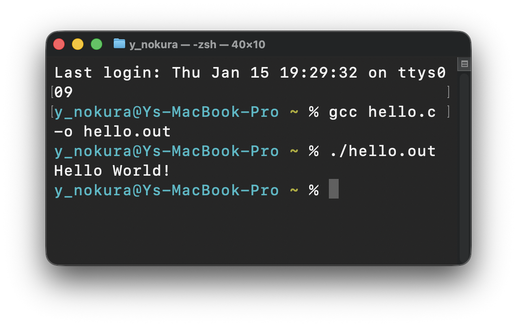

**書き方**

```
Quarto
```

```markdown
::::{.columns}
:::{.column width="39%"}

**コード**

#| code-line-numbers: true

#include <stdio.h>

int main(void)
{
    printf("Hello World!\n");
    return 0;
}

:::
:::{.column width="2%"}
:::
:::{.column width="59%"}

**結果**

![hello.cのコンパイルと実行](img/columns_01.png)

:::
::::
```

**ノート**

カラムはマージン（空白）が入らないため、`2%`程度の空白列を設けるようにすると良い。

また、Quarto独自機能である`::::{.grid}`で囲むことによって、あらかじめマージンがセットされた段組みを記述することができる。グリッド内は12分割されており、`:::{.g-col-6}`のように割合を指定する。

**出力結果**

**コード**

```
hello.c
```

```c
#include <stdio.h>

int main(void)
{
    printf("Hello World!\n");
    return 0;
}
```

**結果**

hello.cのコンパイルと実行

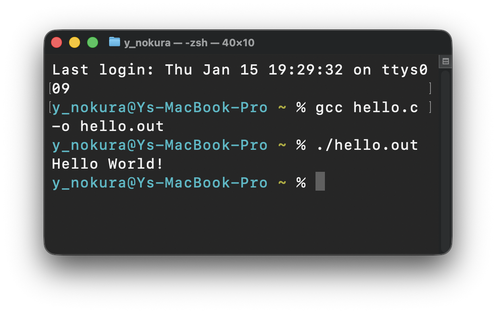

**書き方**

```
Quarto
```

```markdown
::::{.grid}
:::{.g-col-5}

**コード**

#| code-line-numbers: true

#include <stdio.h>

int main(void)
{
    printf("Hello World!\n");
    return 0;
}

:::
:::{.g-col-7}

**結果**

![hello.cのコンパイルと実行](img/columns_01.png)

:::
::::
```

カラムと比較して、図のキャプションに注目すると、空白列を入れていないのにグリッドの隙間に空白が入っているのがわかるだろう。

## パネルタブ

`:::{.panel-tabset}`で囲むことによって、コンテンツをタブごとに切り替えて表示することができる。任意の見出し行（`#`）によって区切る。

**書き方**

```
Quarto
```

```markdown
:::{.panel-tabset}
##### カラム
`::::{.columns}`ブロックで囲むことによって、複数行に段組みして記述することができる。各行は`:::{.column width="50%"}`で幅を指定しながら囲むことができる。

##### グリッド
Quarto独自機能である`::::{.grid}`で囲むことによって、あらかじめマージンがセットされた段組みを記述することができる。グリッド内は12分割されており、`:::{.g-col-6}`のように割合を指定する。
:::
```

**出力結果**

**カラム**

`::::{.columns}`ブロックで囲むことによって、複数行に段組みして記述することができる。各行は`:::{.column width="50%"}`で幅を指定しながら囲むことができる。

**グリッド**

Quarto独自機能である`::::{.grid}`で囲むことによって、あらかじめマージンがセットされた段組みを記述することができる。グリッド内は12分割されており、`:::{.g-col-6}`のように割合を指定する。

# その他

- HTMLタグの`<br>`を入れることにより、強制的に改行する事ができる。
- ハイパーリンクの後ろに{target=“_blank”}を入れると、リンクを新しいタブで開く事ができる。また`{.external target="_blank"}`とすると、リンクの後ろに外部サイトを表すアイコンが付く。
  - [Quarto公式](https://quarto.org)
- `:::{style="<css style>"}`で囲むことにより、ブロック内にCSSスタイルを指定できる。

**ヒント**

特に、`:::{style="margin-left: 2em;"}`は左に２文字分（`em`が文字単位）の余白を開けたスタイルを適用でき、箇条書き内に（下の画像のように）画像や（このブロックのように）コールアウトを入れるときに有効。

- （上と関連して）コードブロック（`{python style="margin-left: 2em;"}`）コールアウトブロック（`{.callout-tip style="margin-left: 2em;"}`）にも、ブロックで囲むことなく個別に余白やその他スタイルを指定可能。

**警告注意**

画像にも`![](img.jpg){style="margin-left: 2em;"}` のようにスタイルを指定できるが、キャプションには適用されない。

- YAMLヘッダーに`lightbox: true`を入れると写真をクリックしたときに拡大表示できる。

善光寺（写真をクリックして拡大）

[figure not shown]

# 参考になるサイト

[**R入門**](https://sb8001at-oss.github.io/Rnyuumon.io/)

- [36 Quarto：Quartoの始め方](https://sb8001at-oss.github.io/Rnyuumon.io/chapter36.html)
- [37 Quarto：Markdownとレイアウト](https://sb8001at-oss.github.io/Rnyuumon.io/chapter37.html)
- [38 Quarto：chunkとchunk option](https://sb8001at-oss.github.io/Rnyuumon.io/chapter38.html)
- [39 Quarto：YAMLの基礎](https://sb8001at-oss.github.io/Rnyuumon.io/chapter39.html)
- [42 Quarto：WebsiteとBook](https://sb8001at-oss.github.io/Rnyuumon.io/chapter42.html)

[**私たちのR**](https://www.jaysong.net/Rbook/)

- [24 Quarto [基礎]](https://www.jaysong.net/RBook/quarto1.html)
- [25 Quarto [文書]](https://www.jaysong.net/RBook/quarto2.html)

[**Quarto公式リファレンス（英語）**](https://quarto.org/docs/reference.html)